# Relatório Municipal de Indicadores 2023

Maracanã, Pará

SAGICAD e SNAS / MDS

# 1 ID CRAS: Indice de Desenvolvimento do CRAS

O ID CRAS é um indicador composto por três dimensões. Cada dimensão possui uma nota na qual quanto mais próxima de 5, melhor o índice e, do contrário, insatisfatório.

O Gráfico 1 mostra a evolução das médias do ID CRAS ao longo dos anos no município de Maracanã, Pará.

Gráfico 1. Evolução das médias do ID CRAS, 2014 a 2023: Maracanã, Pará

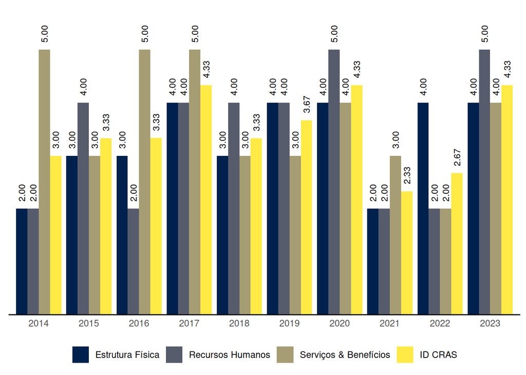

Tabela 1. Quantidade de CRAS em 2023 no município de Maracanã por capacidade de referenciamento.

Quantidade de CRAS em 2023 no município de Maracanã por capacidade de referenciamento.

| Capacidade de até: | Quantidade |
| --- | --- |
| 2.500 famílias referenciadas | 0 |
| 3.500 famílias referenciadas | 1 |
| 5.000 famílias referenciadas | 0 |

As seções a seguir apresentam os resultados do município de Maracanã em cada uma das dimensões do ID CRAS, bem como os requisitos para se alcançar os níveis superiores.

## 1.1 ID CRAS: Dimensão Estrutura Física

### 1.1.1 CRAS com capacidade de referenciamento para até 2.500 ou 3.500 famílias

Na dimensão Estrutura Física, o nível de ID do CRAS com capacidade de referenciamento para até 2.500 ou 3.500 famílias no município de Maracanã é 4.

O CRAS de **nível 4**, com capacidade de referenciamento para até 2.500 ou 3.500 famílias, na dimensão Estrutura Física:

- Possui **recepção**; e
- Possui no mínimo **2 salas de atendimento**, sendo **pelo menos 1 com capacidade para 15 ou mais pessoas**; e
- Possui no mínimo **2 banheiros**; e
- Possui **acessibiliadade, ao menos parcial**; e
- Possui **pelo menos 1 computador conectado à internet**.

Para alcançar o **nível 5** na dimensão Estrutura Física, o CRAS com capacidade de referenciamento para até 2.500 ou 3.500 famílias precisa, além dos requisitos do nível 4:

- Possuir no mínimo **1 sala administrativa**; e
- Possuir **acessibilidade**; e
- Possuir conjunto de equipamentos que inclua, no mínimo: **2 computadores conectados à internet, impressora, telefone e veículo exclusivo ou compartilhado**.

### 1.1.2 CRAS com capacidade de referenciamento para até 5.000 famílias

Maracanã não tem CRAS com capacidade de referenciamento para até 5.000 famílias.

## 1.2 ID CRAS: Dimensão Recursos Humanos

### 1.2.1 CRAS com capacidade de referenciamento para até 2.500 famílias

Maracanã não tem CRAS com capacidade de referenciamento para até 2.500 famílias.

### 1.2.2 CRAS com capacidade de referenciamento para até 3.500 famílias

Na dimensão Recursos Humanos, o nível de ID do CRAS com capacidade de referenciamento para até 3.500 famílias no município de Maracanã é 5.

O CRAS de **nível 5**, com capacidade de referenciamento para até 3.500 famílias, na dimensão Recursos Humanos:

- Possui no mínimo **7** (11, se EV) **profissionais**, sendo pelo menos **4** (6, se EV) com **nível superior**; e
- Possui no mínimo **2 Assistentes Sociais** (3, se EV) e **1 Psicólogo**; e
- Possui no mínimo **1** profissional de nível superior com **vínculo estatutário ou empregado público celetista**; e
- Possui **coordenador** com nível superior.

### 1.2.3 CRAS com capacidade de referenciamento para até 5.000 famílias

Maracanã não tem CRAS com capacidade de referenciamento para até 5.000 famílias.

## 1.3 ID CRAS: Dimensão Serviços & Benefícios

Na dimensão Serviços & Benefícios, o nível de ID do CRAS no município de Maracanã é 4.

O CRAS de **nível 4** na dimensão Serviços & Benefícios em município de porte Pequeno II:

- Tem **quantidade média de famílias em acompanhamento no mês, dividida pela equipe técnica** (Assistentes Sociais e Psicólogos) não inferior a 20 nem superior a 100; e
- **Executa o PAIF** realizando no mínimo as seguintes atividades: **acompanhamento de famílias; grupo/oficina com famílias; visitas domiciliares; palestras, campanhas ou eventos comunitários; orientação/acompanhamento para inserção no BPC e acompanhamento dos encaminhamentos realizados**; e
- Possui oferta de Serviço de Convivência **para no mínimo dois ciclos de vida** (oferta direta do CRAS ou por meio de unidades a ele referenciadas); e
- Possui **forte articulação com o(s) CREAS e com os Serviços de Educação e Saúde** no território; e
- **Funciona** no mínimo **5 dias** por semana e **40 horas** semanais.

Para alcançar o **nível 5** na dimensão Serviços & Benefícios, o CRAS em município de porte Pequeno II precisa, além dos requisitos do nível 4:

- Possuir profissionais de Serviço Social e de Psicologia; e
- Possuir oferta de Serviço de Convivência, **para no mínimo três ciclos de vida** (oferta direta do CRAS ou por meio de unidades a ele referenciadas); e
- **Realizar no próprio CRAS o cadastramento/atualização cadastral do CadÚnico**, sem utilizar para isso os profissionais de nível superior do PAIF.

# 2 ID CREAS: Indice de Desenvolvimento do CREAS

O ID CREAS é um indicador composto por três dimensões. Cada dimensão possui uma nota na qual quanto mais próxima de 5, melhor o índice e, do contrário, insatisfatório.

O Gráfico 2 mostra a evolução das médias do ID CREAS ao longo dos anos no município de Maracanã, Pará.

Gráfico 2. Evolução das médias do ID CREAS, 2014 a 2023: Maracanã, Pará

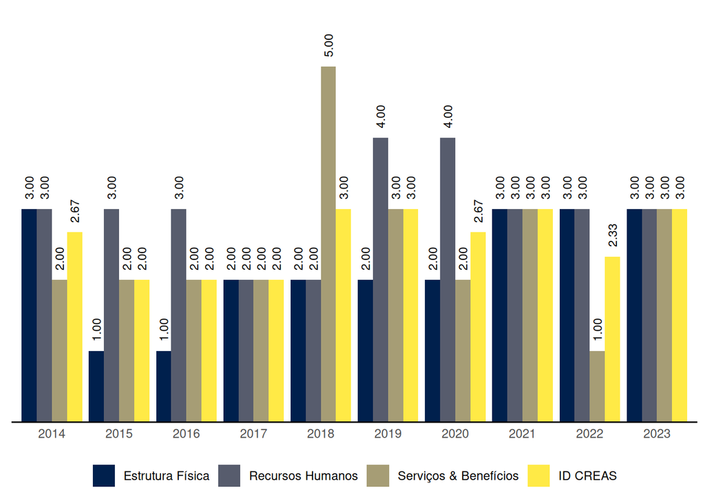

As seções a seguir apresentam os resultados do município de Maracanã em cada uma das dimensões do ID CREAS, bem como os requisitos para se alcançar os níveis superiores.

## 2.1 ID CREAS: Dimensão Estrutura Física

Na dimensão Estrutura Física, o nível de ID do CREAS no município de Maracanã é 3.

O CREAS de **nível 3** na dimensão Estrutura Física em município de porte Pequeno II:

- Possui no mínimo 3 salas (atendimento e/ou administrativa); e
- Possui recepção; e
- Possui no mínimo 1 banheiro; e
- Possui acessibilidade, ao menos parcial.

Para alcançar o **nível 4** na dimensão Estrutura Física, o CREAS em município de porte Pequeno II precisa, além dos requisitos do nível 3:

- Possuir no mínimo 2 banheiros; e
- Possuir 1 ou mais computadores com Internet; e
- Possuir veículo próprio ou compartilhado; e
- Possuir 3 salas ou mais para atendimento (5 se CREAS Regional).

## 2.2 ID CREAS: Dimensão Recursos Humanos

Na dimensão Recursos Humanos, o nível de ID do CREAS no município de Maracanã é 3.

O CREAS de **nível 3** na dimensão Recursos Humanos em município de porte Pequeno II:

- Possui Coordenador com nível superior; e
- Tem quantidade total de trabalhadores (nível superior e médio) maior ou igual a 5 (10, se CREAS Regional), sendo no mínimo 3 (5, se CREAS Regional) deles de nível superior; e
- Possui no mínimo 1 Assistente Social e 1 Psicólogo (além disso, se for CREAS Regional, o total de Assistentes Sociais mais Psicólogos deve ser maior ou igual a 4).

Para alcançar o **nível 4** na dimensão Recursos Humanos, o CREAS em município de porte Pequeno II precisa, além dos requisitos do nível 3:

- Possuir no mínimo 1 Advogado; e
- Ter no mínimo 4 trabalhadores de nível superior (6, se CREAS Regional).

## 2.3 ID CREAS: Dimensão Serviços & Benefícios

Na dimensão Serviços & Benefícios, o nível de ID do CREAS no município de Maracanã é 3.

O CREAS de **nível 3** na dimensão Serviços & Benefícios em município de porte Pequeno II:

- Oferta o PAEFI assegurando a realização, pelo menos, das seguintes atividades: Entrevistas de acolhida para avaliação inicial dos casos, Atendimento psicossocial individual/familiar, Construção de Plano Individual e/ou Familiar de atendimento, Visitas domiciliares e Elaboração de relatórios técnicos sobre casos em acompanhamento; e
- Possui forte articulação com o CRAS e com o Conselho Tutelar; e
- Oferta atendimento para variadas situações de violência ou violação de direitos e para os diferentes ciclos de vida; e
- Oferta o Serviço de MSE (APLICA-SE SOMENTE SE O MUNICÍPIO RECEBER COFINANCIAMENTO ou se for CREAS Regional).

Para alcançar o **nível 4** na dimensão Serviços & Benefícios, o CREAS em município de porte Pequeno II precisa, além dos requisitos do nível 3:

- Ofertar o PAEFI assegurando a realização da atividade de Atendimento psicossocial em grupo (além da realização das atividades exigidas no nível 3); e
- Ter quantidade média de casos em acompanhamento no mês, dividida pela equipe técnica (AS + PSI) menor ou igual a 50 casos; e
- Ofertar o Serviço de MSE assegurando a elaboração do Plano Individual de Atendimento (PIA) do adolescente (APLICA-SE SOMENTE SE O MUNICÍPIO RECEBER COFINANCIAMENTO ou se for CREAS Regional); e
- Ofertar o Serviço de Abordagem ou ter o Serviço referenciado (APLICA-SE SOMENTE SE O MUNICÍPIO RECEBER COFINANCIAMENTO ou se for CREAS Regional).

# 3 ID Conselho: Indice de Desenvolvimento dos Conselhos de Assistência Social

O ID Conselho é indicador desenvolvimento com o objetivo de avaliar o controle social no SUAS. Ele possui três dimensões. Cada dimensão possui uma nota na qual quanto mais próxima de 5, melhor o índice e, do contrário, insatisfatório.

O Gráfico 3 mostra a evolução das médias do ID Conselho ao longo dos anos no município de Maracanã, Pará.

Gráfico 3. Evolução das médias do ID Conselho, 2014 a 2023: Maracanã, Pará

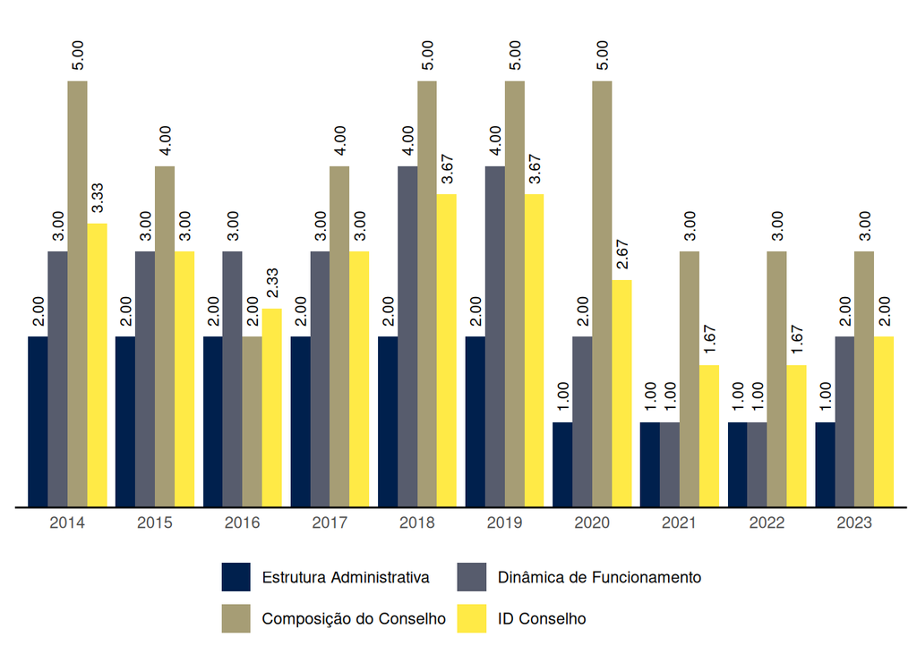

As seções a seguir apresentam os resultados do município de Maracanã em cada uma das dimensões do ID Conselho, bem como os requisitos para se alcançar os níveis superiores.

## 3.1 ID Conselho: Dimensão Estrutura Administrativa

Na dimensão Estrutura Administrativa, o nível de ID do Conselho no município de Maracanã é 1.

O Conselho de **nível 1** na dimensão Estrutura Administrativa em município de porte Pequeno II:

- **Não** possui previsão de recursos na Lei Orçamentária Anual e **não** utiliza para as despesas de seu funcionamento o mínimo de 3% do IGD; ou
- **Não** possui sala (exclusiva ou compartilhada); ou
- **Não** possui Secretaria Executiva.

Para alcançar o **nível 2** na dimensão Estrutura Administrativa, o Conselho em município de porte Pequeno II precisa:

- Possuir previsão de recursos na Lei Orçamentária Anual ou utilizar para as despesas de seu funcionamento o mínimo de 3% do IGD; e
- Possuir uma ou mais salas de uso exclusivo ou compartilhado; e
- Possuir Secretaria Executiva.

## 3.2 ID Conselho: Dimensão Dinâmica de Funcionamento

Na dimensão Dinâmica de Funcionamento, o nível de ID do Conselho no município de Maracanã é 2.

O Conselho de **nível 2** na dimensão Dinâmica de Funcionamento em município de porte Pequeno II:

- Realizou 6 ou mais reuniões plenárias no ano anterior (ordinárias e extraordinárias); e
- Deliberou sobre o Plano de Assistência Social.

Para alcançar o **nível 3** na dimensão Dinâmica de Funcionamento, o Conselho em município de porte Pequeno II precisa, além dos requisitos do nível 2:

- Possuir Regimento Interno; e
- Acompanhar o cumprimento de deliberações da Conferência Municipal.

## 3.3 ID Conselho: Dimensão Composição do Conselho

Na dimensão Composição do Conselho, o nível de ID do Conselho no município de Maracanã é 3.

O Conselho de **nível 3** na dimensão Composição do Conselho em município de porte Pequeno II:

- Possui no mínimo 6 conselheiros titulares; e
- Possui pelo menos um conselheiro titular representante de usuários ou organização de usuários; e
- Possui pelo menos um conselheiro titular representante de trabalhadores do setor; e
- Possui alternância na presidência entre os representantes de governo e os representantes da sociedade civil.

Para alcançar o **nível 4** na dimensão Composição do Conselho, o Conselho em município de porte Pequeno II precisa, além dos requisitos do nível 3:

- Possuir representantes da sociedade civil eleitos por assembleias constituídas para esse fim; e
- Possuir Presidente e Vice-Presidente eleitos em plenária; e
- Que o Conselheiro possa ser reconduzido uma única vez.